# HW1

```python
import cantera as ct
import numpy as np
import scipy
import pylab
import matplotlib
import matplotlib.pyplot as plt
import pandas as pd
import os
from IPython.display import Image
```

```python
# import the file
gas = ct.Solution('propanepyrolysis.cti', 'gas')
print(f"This mechanism contains {gas.n_reactions} gas reactions")
```

```
This mechanism contains 668 gas reactions
```

```python
gas.species_names
```

```
['He',
 'Ne',
 'propane(1)',
 'H(2)',
 'H2(6)',
 'CH3(14)',
 'CH4(15)',
 'C2H6(36)',
 'C2H5(37)',
 'C2H4(38)',
 'C2H3(41)',
 'C3H3(66)',
 'NC3H7(92)',
 'IC3H7(93)',
 'C3H5-A(94)',
 'C3H6(95)',
 'C3H5(101)',
 'C4H5(106)',
 'C4H5(107)',
 'C3H4(167)',
 'C3H4(169)',
 'PC4H9(183)',
 'SC4H9(184)',
 'C4H8(189)',
 'C4H8(190)',
 'C4H7(191)',
 'C4H7(192)',
 'C4H7(193)',
 'C4H6(195)',
 'IC4H9(273)',
 'C6H10(342)',
 'C6H9(343)',
 'C5H9(399)',
 'C5H9(400)',
 'C5H8(403)',
 'C5H7(404)',
 'C5H9(405)',
 'C5H9(407)',
 'C5H11(421)',
 'C5H11(422)',
 'C5H9(428)',
 'C5H11(537)',
 'C5H11(540)',
 'C5H10(541)',
 'C4H6(770)',
 'C4H5(774)',
 'C4H7(777)',
 'C4H5(781)',
 'C4H5(793)',
 'C3H4(801)']
```

```python
gas.species_name(1)
```

```
'Ne'
```

# Problem 1a

```python
# initial conditions
temp = 1000  # K
pressure = ct.one_atm
X = "H(2):1, C2H6(36):100000"
# X = "H2(6):1, C2H6(36):100000"
gas.TPX = temp, pressure, X
# r.volume = 1

r = ct.IdealGasConstPressureReactor(gas, energy='off')
sim = ct.ReactorNet([r])
sim.max_err_test_fails = 12
sim.rtol = 1.0e-12
sim.atol = 1.0e-23
states = ct.SolutionArray(gas, extra=['t'])
rxn_time = np.arange(0,1e-6,1e-12)  # linear spacing
# rxn_time = np.logspace(0,1e-6,num=1e9)  # log spacing

gas_mole_fracs = np.zeros([gas.n_species, len(rxn_time)])
temperature = np.zeros(len(rxn_time))
v = np.zeros(len(rxn_time))

# print('  Time    H2(6)    C2H6(36)   Temp')
for i in range(len(rxn_time)):
    time = rxn_time[i]  # define time in the reactor
    sim.advance(time)  # Advance the simulation to next set time
    gas_mole_fracs[:, i] = gas.X
    temperature[i] = gas.T
    v[i] = r.volume
```

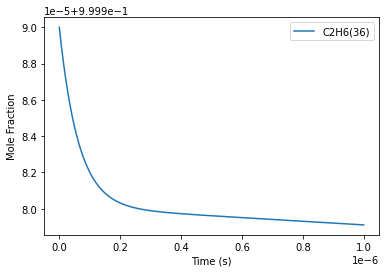

```python
for species in range(gas.n_species):
    if gas_mole_fracs[species].max() > 5.e-3:
        plt.plot(rxn_time, gas_mole_fracs[species], label=gas.species_name(species))
plt.legend()
plt.xlabel('Time (s)')
plt.ylabel('Mole Fraction')
# plt.plot(rxn_time, gas_mole_fracs[gas.species_index('H2(6)')])
# plt.plot(rxn_time, gas_mole_fracs[gas.species_index('C2H6(36)')])
```

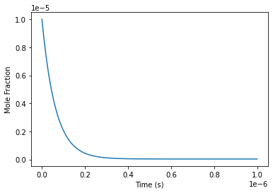

```python
plt.plot(rxn_time, gas_mole_fracs[gas.species_index('H(2)')])
plt.xlabel('Time (s)')
plt.ylabel('Mole Fraction')
```

```python
def half_life(gas_mole_fracs, species):
    H_mole_fracs = gas_mole_fracs[gas.species_index(species)]

    H_half_life_amount = H_mole_fracs[0]/2.
    for x in H_mole_fracs:
        if x <= H_half_life_amount:
    #         H_half_life = H_mole_fracs.index(x)
            H_half_life_time = np.where(H_mole_fracs == x)
            break
    H_half_life = rxn_time[H_half_life_time[0][0]]
    print(H_half_life_time[0][0])

    return H_half_life

H_half_life = half_life(gas_mole_fracs, 'H(2)')
print(f"The half life for an H atom is {H_half_life} seconds.")
```

```
43677
The half life for an H atom is 4.3677e-08 seconds.
```

```python
ethane_mole_fracs = gas_mole_fracs[gas.species_index('C2H6(36)')]
ethane_change = ethane_mole_fracs[0] - ethane_mole_fracs[43677]
print(f"The mole fraction change of ethane after {H_half_life} seconds is {ethane_change}.")
```

```
The mole fraction change of ethane after 4.3677e-08 seconds is 5.008620124313801e-06.
```

The mole fraction of ethane does not change significantly in this small timescale

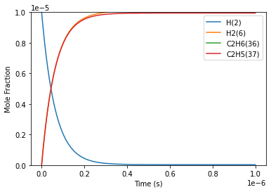

```python
for species in range(gas.n_species):
    if gas_mole_fracs[species].max() > 5.e-6:
        plt.plot(rxn_time, gas_mole_fracs[species], label=gas.species_name(species))
plt.ylim(0,1e-5)
plt.ylabel('Mole Fraction')
plt.xlabel('Time (s)')
plt.legend()
```

H<sub>2</sub> and C<sub>2</sub>H<sub>5</sub> species are being formed.

```python
reactions_of_interest = []

for rxn in gas.reactions():
    if ('H(2)' and 'C2H6(36)') in rxn.reactants:
        if ('H2(6)' or 'C2H5(37)') in rxn.products:
            print(f"Could be {rxn.equation}, ID: {rxn.ID}")
            print(f"rate: {rxn.rate}")
            reactions_of_interest.append(rxn)
```

```
Could be C2H6(36) + H(2) <=> C2H5(37) + H2(6), ID: 0026
rate: Arrhenius(A=115000, b=1.9, E=3.15055e+07)
```

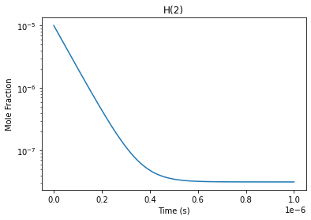

```python
plt.semilogy(rxn_time, gas_mole_fracs[gas.species_index('H(2)')])
plt.ylabel('Mole Fraction')
plt.xlabel('Time (s)')
# plt.xlim(0,3e-7)
plt.title('H(2)')
```

H is linear at short times, as expected!

At longer times, the slope of H becomes horizontal (or close to it)

# Problem 1b

Start with:

$x(t) = x_0 (\frac{1}{2})^\frac{t}{t_{1/2}}$

where:

$x(t)$ is the mole fraction of H atoms at some time, $t$, $x_0$ is the initial quantity of H atoms at the start, $t = 0$, and $t_{1/2}$ is the half-life.

Solve for $t_{1/2}$:

$\frac{x}{x_0} = (\frac{1}{2})^\frac{t}{t_{1/2}} = 2^{-\frac{t}{t_{1/2}}}$

flip both sides

$\frac{x_0}{x} = 2^\frac{t}{t_{1/2}}$

take $log_2$ of both sides

$log_2(\frac{x_0}{x}) = \frac{t}{t_{1/2}} = \frac{ln(\frac{x_0}{x})}{ln(2)}$

flip both sides back again and multiply both sides by $t$

$t_{1/2} = \frac{ln(2)}{ln(\frac{x_0}{x})} t$

...???

```python
A = reactions_of_interest[0].rate.pre_exponential_factor
B = reactions_of_interest[0].rate.temperature_exponent
Ea = reactions_of_interest[0].rate.activation_energy
T = 1000.  # Kelvin
expected_k = A * T**B * np.exp(1) ** (-Ea/(ct.gas_constant * T))

print(f"Expected K from chem.inp file: {expected_k} m^3 * kmol^-1 * s^-1")
```

```
Expected K from chem.inp file: 1303317943.333642 m^3 * kmol^-1 * s^-1
```

# Problem 1c

```python
rxn_time = np.arange(0,1e-5,1e-12)  # changing reactor time to the short timescale
dk = 1e-2
sensitivities = pd.DataFrame(data=[], index=gas.reaction_equations(range(gas.n_reactions)))
sensitivities["baseCase"] = ""

temp = 1000  # K
pressure = ct.one_atm
X = "H(2):1, C2H6(36):100000"
gas.TPX = temp, pressure, X

r = ct.IdealGasConstPressureReactor(gas, energy='off')
sim = ct.ReactorNet([r])
sim.max_err_test_fails = 12
sim.rtol = 1.0e-12
sim.atol = 1.0e-23
states = ct.SolutionArray(gas, extra=['t'])

for m in range(gas.n_reactions):
    gas.set_multiplier(1.0)
    gas.set_multiplier(1+dk, m)

    gas_mole_fracs = np.zeros([gas.n_species, len(rxn_time)])

    for i in range(len(rxn_time)):
        time = rxn_time[i]  # define time in the reactor
        sim.advance(time)  # Advance the simulation to next set time
        gas_mole_fracs[:, i] = gas.X


    new_H_half_life = half_life(gas_mole_fracs, 'H(2)')
    sensitivities["baseCase"][m] = (new_H_half_life - H_half_life)/(H_half_life*dk)

gas.set_multiplier(1.0)
```

[output not shown]

```python
sensitivities
```

[output not shown]

# Problem 2a

```python
# initial conditions
temp = 1000  # K
pressure = ct.one_atm
X = "C2H6(36):1"
gas.TPX = temp, pressure, X

r = ct.IdealGasConstPressureReactor(gas, energy='off')
sim = ct.ReactorNet([r])
sim.max_err_test_fails = 12
sim.rtol = 1.0e-12
sim.atol = 1.0e-23
states = ct.SolutionArray(gas, extra=['t'])
rxn_time = np.arange(0,5,1e-5)  # linear spacing
# rxn_time = np.logspace(1e-20,5,num=1e8)  # log spacing

gas_mole_fracs = np.zeros([gas.n_species, len(rxn_time)])

# print('  Time    H2(6)    C2H6(36)   Temp')
for i in range(len(rxn_time)):
    time = rxn_time[i]  # define time in the reactor
    sim.advance(time)  # Advance the simulation to next set time
    gas_mole_fracs[:, i] = gas.X
```

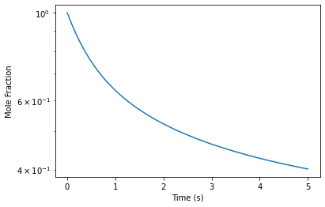

```python
plt.semilogy(rxn_time, gas_mole_fracs[gas.species_index('C2H6(36)')])
plt.xlabel("Time (s)")
plt.ylabel("Mole Fraction")
```

```python
ethane_half_life = half_life(gas_mole_fracs, 'C2H6(36)')
print(f"The half life of ethane is {ethane_half_life} seconds")
```

```
232423
The half life of ethane is 2.32423 seconds
```

Ethane decay is not a pseudo-first order process

# Problem 2b

```python
# initial conditions
temp = 1000  # K
pressure = ct.one_atm
X = "C2H6(36):1"
gas.TPX = temp, pressure, X

r = ct.IdealGasConstPressureReactor(gas, energy='off')
sim = ct.ReactorNet([r])
sim.max_err_test_fails = 12
sim.rtol = 1.0e-12
sim.atol = 1.0e-23
# states = ct.SolutionArray(gas, extra=['t'])
rxn_time = np.arange(0,2.32423,1e-5)  # linear spacing

gas_mole_fracs = np.zeros([gas.n_species, len(rxn_time)])

for i in range(len(rxn_time)):
    time = rxn_time[i]  # define time in the reactor
    sim.advance(time)  # Advance the simulation to next set time
    gas_mole_fracs[:, i] = gas.X

    if i == 232422:
        diagram = ct.ReactionPathDiagram(gas, 'C')
        diagram.title = 'C-rxnpath'
        diagram.label_threshold = 1e-9
        dot_file = f"C-fluxdiagram.dot"
        img_file = f"C-fluxdiagram.png"
        diagram.write_dot(dot_file)
        os.system('dot {0} -Tpng -o{1} -Gdpi=200'.format(dot_file, img_file))

        diagram = ct.ReactionPathDiagram(gas, 'H')
        diagram.title = 'H-rxnpath'
        diagram.label_threshold = 1e-9
        dot_file = f"H-fluxdiagram.dot"
        img_file = f"H-fluxdiagram.png"
        diagram.write_dot(dot_file)
        os.system('dot {0} -Tpng -o{1} -Gdpi=200'.format(dot_file, img_file))
```

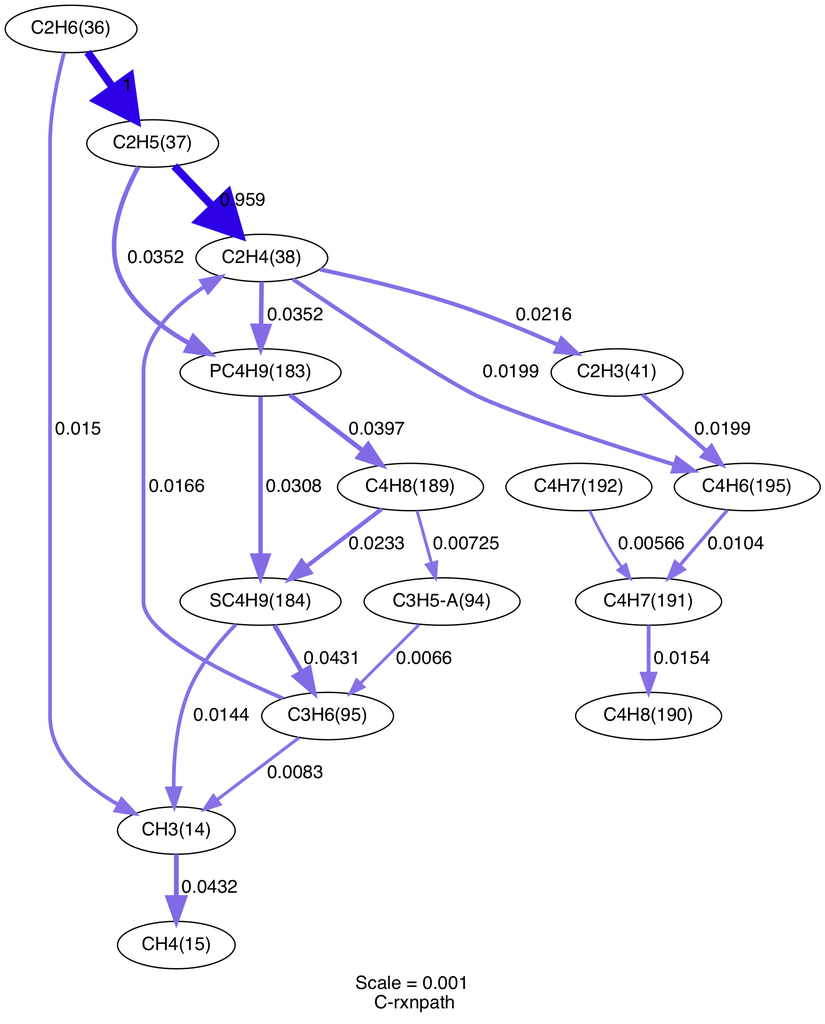

```python
Image(filename="C-fluxdiagram.png")
```

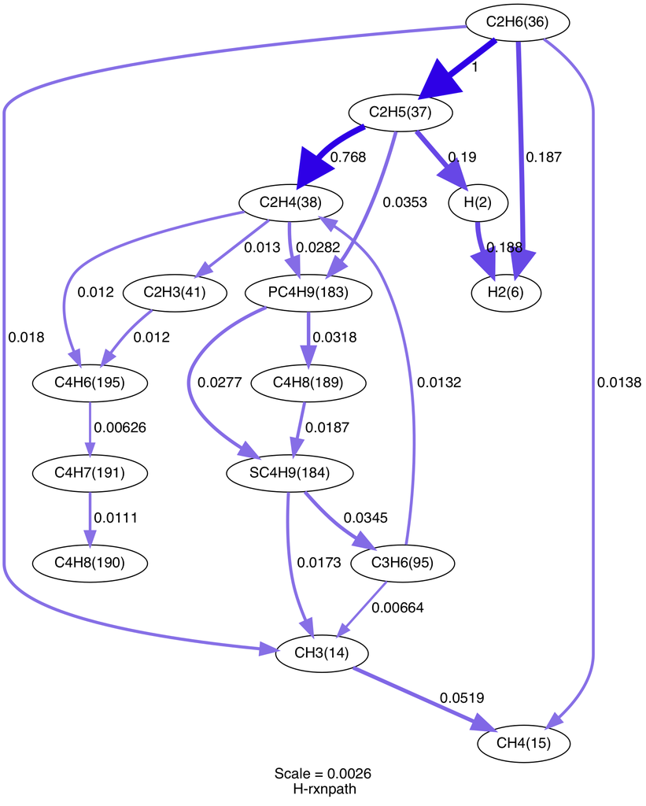

```python
Image(filename="H-fluxdiagram.png")
```

```python
reactions_of_interest = []

for rxn in gas.reactions():
    if ('C2H6(36)') in rxn.reactants:
        if ('H2(6)' or 'C2H5(37)' or 'CH3(14)') in rxn.products:
            print(f"Could be {rxn.equation}, ID: {rxn.ID}")
            reactions_of_interest.append(rxn)
```

```
Could be C2H6(36) + H(2) <=> C2H5(37) + H2(6), ID: 0026
```

```python
for rxn in gas.reactions():
    if ('C2H5(37)') in rxn.reactants:
        if ('H2(6)') in rxn.products:
            print(f"Could be {rxn.equation}, ID: {rxn.ID}")
            reactions_of_interest.append(rxn)
```

```
Could be C2H5(37) + H(2) <=> C2H4(38) + H2(6), ID: 0027
```

```python
print(f"The main reaction consuming CH$_4$ at time = {ethane_half_life} is reaction {reactions_of_interest[0]}.")
```

[output not shown]

```python
print(f"The sequence of balanced reactions converting C2H6 into C2H4 is:\n",
      f"{reactions_of_interest[0]}\n",
      f"{reactions_of_interest[1]}")
```

```
The sequence of balanced reactions converting C2H6 into C2H4 is:
 C2H6(36) + H(2) <=> C2H5(37) + H2(6)
 C2H5(37) + H(2) <=> C2H4(38) + H2(6)
```